```python
import numpy as np
import pandas as pd
import matplotlib.pyplot as plt
import seaborn as sns
```

```python
df= pd.read_excel ("D:\\assignment\\facebook_user_data.xlsx")
```

```python
df.info()
```

```
<class 'pandas.core.frame.DataFrame'>
RangeIndex: 99003 entries, 0 to 99002
Data columns (total 15 columns):
 #   Column                 Non-Null Count  Dtype
---  ------                 --------------  -----
 0   userid                 99003 non-null  int64
 1   age                    99003 non-null  int64
 2   dob_day                99003 non-null  int64
 3   dob_year               99003 non-null  int64
 4   dob_month              99003 non-null  int64
 5   gender                 98828 non-null  object
 6   tenure                 99001 non-null  float64
 7   friend_count           99003 non-null  int64
 8   friendships_initiated  99003 non-null  int64
 9   likes                  99003 non-null  int64
 10  likes_received         99003 non-null  int64
 11  mobile_likes           99003 non-null  int64
 12  mobile_likes_received  99003 non-null  int64
 13  www_likes              99003 non-null  int64
 14  www_likes_received     99003 non-null  int64
dtypes: float64(1), int64(13), object(1)
memory usage: 11.3+ MB
```

```python
df.head(5)
```

|  | userid | age | dob_day | dob_year | dob_month | gender | tenure | friend_count | friendships_initiated | likes | likes_received | mobile_likes | mobile_likes_received | www_likes | www_likes_received |
| --- | --- | --- | --- | --- | --- | --- | --- | --- | --- | --- | --- | --- | --- | --- | --- |
| 0 | 2094382 | 14 | 19 | 1999 | 11 | male | 266.0 | 0 | 0 | 0 | 0 | 0 | 0 | 0 | 0 |
| 1 | 1192601 | 14 | 2 | 1999 | 11 | female | 6.0 | 0 | 0 | 0 | 0 | 0 | 0 | 0 | 0 |
| 2 | 2083884 | 14 | 16 | 1999 | 11 | male | 13.0 | 0 | 0 | 0 | 0 | 0 | 0 | 0 | 0 |
| 3 | 1203168 | 14 | 25 | 1999 | 12 | female | 93.0 | 0 | 0 | 0 | 0 | 0 | 0 | 0 | 0 |
| 4 | 1733186 | 14 | 4 | 1999 | 12 | male | 82.0 | 0 | 0 | 0 | 0 | 0 | 0 | 0 | 0 |

Imputation of missing values:

```python
df.columns
```

```
Index(['userid', 'age', 'dob_day', 'dob_year', 'dob_month', 'gender', 'tenure',
       'friend_count', 'friendships_initiated', 'likes', 'likes_received',
       'mobile_likes', 'mobile_likes_received', 'www_likes',
       'www_likes_received'],
      dtype='object')
```

```python
df.isna().sum()
```

```
userid                     0
age                        0
dob_day                    0
dob_year                   0
dob_month                  0
gender                   175
tenure                     2
friend_count               0
friendships_initiated      0
likes                      0
likes_received             0
mobile_likes               0
mobile_likes_received      0
www_likes                  0
www_likes_received         0
dtype: int64
```

Replace the null values (NA) of gender column with its mode or median and explain why mode/median used to replace NA values

```python
df.duplicated().sum()
```

```
0
```

```python
df['gender'].fillna(df['gender'].mode,inplace= True)
```

ANS- Its a categorical variable so i used mode.

```python
df.isna().sum()
```

```
userid                   0
age                      0
dob_day                  0
dob_year                 0
dob_month                0
gender                   0
tenure                   2
friend_count             0
friendships_initiated    0
likes                    0
likes_received           0
mobile_likes             0
mobile_likes_received    0
www_likes                0
www_likes_received       0
dtype: int64
```

Replace the null values (NA) of tenure column (numerical variable) with its median,and explain why mode/median used to replace NA values

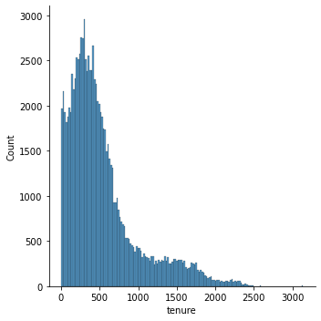

```python
sns.displot(df.tenure)
```

```python
df['tenure'].fillna(df['tenure'].median,inplace= True)
```

When the data is skewed, it is good to consider using the median value for replacing the missing values.

```python
df.isna().sum()
```

```
userid                   0
age                      0
dob_day                  0
dob_year                 0
dob_month                0
gender                   0
tenure                   0
friend_count             0
friendships_initiated    0
likes                    0
likes_received           0
mobile_likes             0
mobile_likes_received    0
www_likes                0
www_likes_received       0
dtype: int64
```

2) Plot heatmap / correlation matrix on all the columns.

```python
df.corr()
```

|  | userid | age | dob_day | dob_year | dob_month | friend_count | friendships_initiated | likes | likes_received | mobile_likes | mobile_likes_received | www_likes | www_likes_received |
| --- | --- | --- | --- | --- | --- | --- | --- | --- | --- | --- | --- | --- | --- |
| userid | 1.000000 | -0.007265 | -0.000839 | 0.007265 | 0.002924 | -0.001314 | -0.001591 | -0.002875 | 0.001526 | -0.004868 | 0.001753 | 0.001828 | 0.001074 |
| age | -0.007265 | 1.000000 | 0.035035 | -1.000000 | 0.025167 | -0.027407 | -0.058059 | -0.013009 | -0.022570 | -0.026715 | -0.024248 | 0.015585 | -0.018224 |
| dob_day | -0.000839 | 0.035035 | 1.000000 | -0.035035 | 0.129443 | 0.021961 | 0.022999 | 0.015980 | 0.001367 | 0.014541 | 0.000497 | 0.009353 | 0.002460 |
| dob_year | 0.007265 | -1.000000 | -0.035035 | 1.000000 | -0.025167 | 0.027407 | 0.058059 | 0.013009 | 0.022570 | 0.026715 | 0.024248 | -0.015585 | 0.018224 |
| dob_month | 0.002924 | 0.025167 | 0.129443 | -0.025167 | 1.000000 | 0.019804 | 0.020075 | 0.014147 | 0.006495 | 0.010400 | 0.006435 | 0.012136 | 0.006003 |
| friend_count | -0.001314 | -0.027407 | 0.021961 | 0.027407 | 0.019804 | 1.000000 | 0.825850 | 0.298017 | 0.236463 | 0.235656 | 0.232701 | 0.229803 | 0.220727 |
| friendships_initiated | -0.001591 | -0.058059 | 0.022999 | 0.058059 | 0.020075 | 0.825850 | 1.000000 | 0.285592 | 0.175131 | 0.229808 | 0.173804 | 0.214022 | 0.161439 |
| likes | -0.002875 | -0.013009 | 0.015980 | 0.013009 | 0.014147 | 0.298017 | 0.285592 | 1.000000 | 0.327376 | 0.871652 | 0.329258 | 0.644960 | 0.295687 |
| likes_received | 0.001526 | -0.022570 | 0.001367 | 0.022570 | 0.006495 | 0.236463 | 0.175131 | 0.327376 | 1.000000 | 0.256998 | 0.973679 | 0.255365 | 0.947990 |
| mobile_likes | -0.004868 | -0.026715 | 0.014541 | 0.026715 | 0.010400 | 0.235656 | 0.229808 | 0.871652 | 0.256998 | 1.000000 | 0.288513 | 0.187619 | 0.190173 |
| mobile_likes_received | 0.001753 | -0.024248 | 0.000497 | 0.024248 | 0.006435 | 0.232701 | 0.173804 | 0.329258 | 0.973679 | 0.288513 | 1.000000 | 0.209997 | 0.850490 |
| www_likes | 0.001828 | 0.015585 | 0.009353 | -0.015585 | 0.012136 | 0.229803 | 0.214022 | 0.644960 | 0.255365 | 0.187619 | 0.209997 | 1.000000 | 0.296053 |
| www_likes_received | 0.001074 | -0.018224 | 0.002460 | 0.018224 | 0.006003 | 0.220727 | 0.161439 | 0.295687 | 0.947990 | 0.190173 | 0.850490 | 0.296053 | 1.000000 |

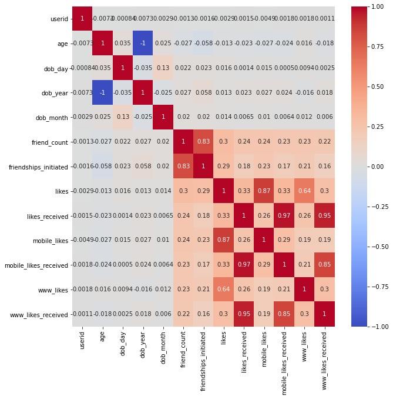

```python
plt.figure(figsize=(10,10))
sns.heatmap(df.corr(), annot =True, cmap="coolwarm")
```

# 3) Analysis based on gender of the users

● What is composition of male and female users?

```python
df['gender'].value_counts()
```

```
male      58574
female    40254
Name: gender, dtype: int64
```

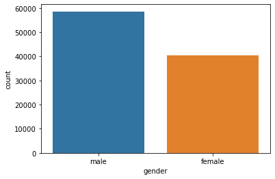

```python
sns.countplot(df['gender'])
```

Which category of gender has more friends?

```python
df.groupby('gender').agg({'friend_count': ['sum']})
```

| gender | friend_count sum |
| --- | --- |
| female | 9740258 |
| male | 9666787 |

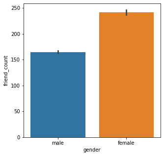

```python
plt.figure(figsize=(5,5))
sns.barplot(x=df.gender,y=df.friend_count)
```

ANS- categories of Feamle has more friends.

# Which category of gender initiated more friendships?

```python
df.groupby('gender').agg({'friendships_initiated': ['sum']})
```

| gender | friendships_initiated sum |
| --- | --- |
| female | 4584894 |
| male | 6037023 |

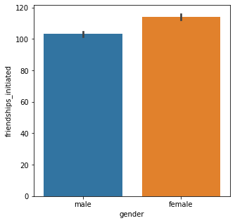

```python
plt.figure(figsize=(5,5))
sns.barplot(x=df.gender,y=df.friendships_initiated)
```

ANS- Female catagory has more friends initiated than male.

# What is the distribution of tenure across different categories of gender?

```python
df.groupby('gender').agg({'tenure': ['sum']})
```

| gender | tenure sum |
| --- | --- |
| female | 23637151.0 |
| male | 29298972.0 |

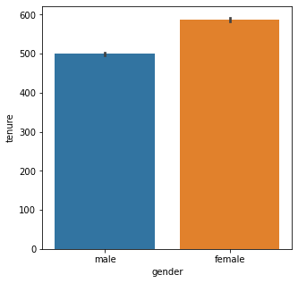

```python
plt.figure(figsize=(5,5))
sns.barplot(y=df.tenure,x=df.gender)
```

ANS- Females are spend more Number of days active on Facebook than males.

# 4) Analysis based on the least active users on Facebook

● How many users have no friends?

```python
df.friend_count.value_counts()
```

```
0       1962
1       1816
2       1117
3        860
5        789
        ...
3299       1
4576       1
2339       1
4384       1
2047       1
Name: friend_count, Length: 2562, dtype: int64
```

ANS- 1962 users don't have friends

# How many users did not like any posts?

```python
df.likes.value_counts()
```

```
0       22308
1        6928
2        4434
3        3240
4        2507
        ...
2087        1
3467        1
6119        1
4068        1
2047        1
Name: likes, Length: 2924, dtype: int64
```

ANS-22308 users did not like any post

# How many users did not receive any likes?

```python
df.likes_received.value_counts()
```

```
0       24428
1        7305
2        4541
3        3347
4        2669
        ...
1610        1
3659        1
3723        1
2660        1
2047        1
Name: likes_received, Length: 2681, dtype: int64
```

ANS-24428 no of users did'nt recive any likes

# Analysis based on the user accessibility (Mobile Devices vs. Web Devices)

What is the average number of posts liked by users (based on gender) through web vs.mobile devices?

```python
a=df.groupby('gender').agg({'mobile_likes': ['mean']})
a
```

| gender | mobile_likes mean |
| --- | --- |
| female | 172.912928 |
| male | 60.261328 |

```python
b=df.groupby('gender').agg({'www_likes': ['mean']})
b
```

| gender | www_likes mean |
| --- | --- |
| female | 87.138297 |
| male | 24.416550 |

```
<BarContainer object of 2 artists>
```

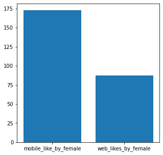

```python
plt.figure(figsize=(5,5))
x=["mobile_like_by_female","web_likes_by_female"]
y=[list(a.loc['female'])][0],list(b.loc['female'])[0]
plt.bar(x,y)
```

```
<BarContainer object of 2 artists>
```

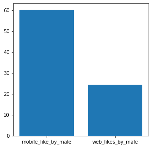

```python
plt.figure(figsize=(5,5))
x=["mobile_like_by_male","web_likes_by_male"]
y=[list(a.loc['male'])][0],list(b.loc['male'])[0]
plt.bar(x,y)
```

What is the average number of likes received by users (based on gender) through web vs. mobile devices?

```python
d=df.groupby('gender').agg({'mobile_likes_received': ['mean']})
d
```

| gender | mobile_likes_received mean |
| --- | --- |
| female | 147.100884 |
| male | 40.833015 |

```python
e=df.groupby('gender').agg({'www_likes_received': ['mean']})
e
```

| gender | www_likes_received mean |
| --- | --- |
| female | 104.334451 |
| male | 27.078533 |

```
<BarContainer object of 2 artists>
```

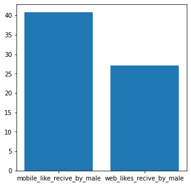

```python
plt.figure(figsize=(5,5))
x=["mobile_like_recive_by_male","web_likes_recive_by_male"]
y=[list(d.loc['male'])][0],list(e.loc['male'])[0]
plt.bar(x,y)
```

```
<BarContainer object of 2 artists>
```

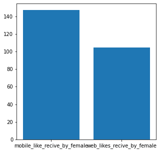

```python
plt.figure(figsize=(5,5))
x=["mobile_like_recive_by_female","web_likes_recive_by_female"]
y=[list(d.loc['female'])][0],list(e.loc['female'])[0]
plt.bar(x,y)
```